# Regression Analysis: Mobility

Akram Nour

9/05/2022

We will use the following data set whose observations are various counties in the U.S. The outcome variable of interest is the “mobility” variable, which is a measure of the causal effect of growing up in a county on a person’s likelihood to attain an income in the top 25% of the income distribution. This measure is taken from the Raj Chetty et. al paper, “Where is the Land of Opporunity? The Geography of Intergenerational Mobility in the United States” (AER, 2014).

The other variables in this dataset are various demographic characteristics of these counties taken from the 2015 CPS (Current Population Survey).

Non-Numeric Variables:

- cz_name: County Zone Name
- stateabbrv: State Abbreviation
- name: County Names

Numeric Variables:

- population: The population of the county
- density: The poulation density of the county (number of people per square mile)
- male: The percentage of the county’s population that is male
- white: The percentage of the county’s population that reports as white
- black: The percentage of the county’s population that reports as black
- amind: The percentage of the county’s population that reports as American Indian
- asian: The percentage of the county’s population that reports as asian
- highschool: The percentage of the county’s population that has graduated highschool
- college: The percentage of the county’s population that has graduated college
- dropout: The percentage of the county’s population that has droppped out of college
- labforce: The percentage of the county’s population that is participating in the labor force
- manufacturing: The percentage of the county’s population that works in manufacturing
- income: The average income of the county
- gini: The county’s gini coeffecient (a measure of income inequality within the county, higher = more unequal)
- rentpct: The average rent as a percentage of income in the county
- poverty: The percentage of the county’s population who are living below the federal poverty line

We would like to explore the (associative!) relationship between these demographic variables and county mobility rates.

## Single Linear Regression

For this section, we will investigate the relationship between average rent as a percentage of income and county mobility rates.

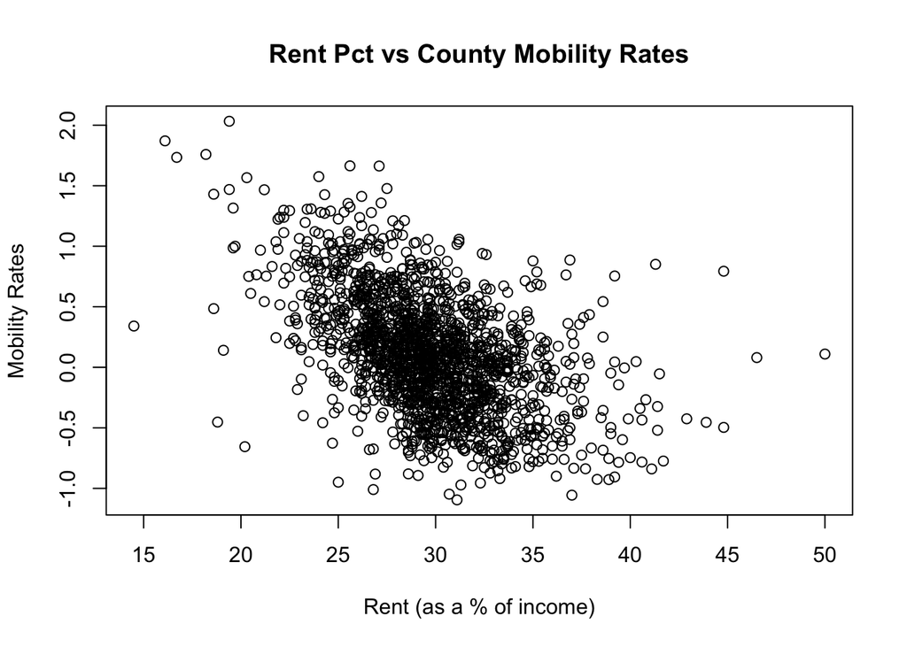

```r
# Put your plot here and discuss below
plot(data$rentpct, data$mobility, xlab = "Rent (as a % of income)", ylab = "Mobility Rates", main = "Rent Pct vs County Mobility Rates")
```

When looking at the relationship between average rent as a percentage of income and county mobility rates, there’s a negative association, meaning that as the average rent as a percentage of income in a county increases, its mobility rate decreases. In terms of linearity, there’s a weak, negative, linear association between the two variables.

## Exploratory Data Analysis

```r
# Code for sample mean, median, and variance of rentpct
rentpct_samplemean <- mean(data$rentpct)
rentpct_samplemean
```

```
## [1] 29.68362
```

```r
rentpct_samplemedian <- median(data$rentpct)
rentpct_samplemedian
```

```
## [1] 29.5
```

```r
rentpct_samplevariance <- var(data$rentpct)
rentpct_samplevariance
```

```
## [1] 13.45944
```

```r
# Code for sample mean, median, and variance of mobility
mobility_samplemean <- mean(data$mobility)
mobility_samplemean
```

```
## [1] 0.1052577
```

```r
mobility_samplemedian <- median(data$mobility)
mobility_samplemedian
```

```
## [1] 0.08697267
```

```r
mobility_samplevar <- var(data$mobility)
mobility_samplevar
```

```
## [1] 0.2272118
```

We can see that for average rent as percentage of income, its sample mean is 29.68362, its sample median is 29.5, and its sample variance is 13.45944. For mobility, the sample mean is 0.1052577, the sample median is 0.08697267, and the sample variance is 0.2272118

## Linear Model

Next, let’s formally investigate this relationship between average rent as a percentage of income and county mobility rates by running a linear regression of mobility against rentpct.

```r
# Code for linear regression
regout <- lm(mobility ~ rentpct, data)
summary(regout)
```

```
##
## Call:
## lm(formula = mobility ~ rentpct, data = data)
##
## Residuals:
##      Min       1Q   Median       3Q      Max
## -1.37767 -0.28213 -0.01569  0.25933  1.67137
##
## Coefficients:
##              Estimate Std. Error t value Pr(>|t|)
## (Intercept)  2.035546   0.080422   25.31   <2e-16 ***
## rentpct     -0.065029   0.002689  -24.18   <2e-16 ***
## ---
## Signif. codes:  0 '***' 0.001 '**' 0.01 '*' 0.05 '.' 0.1 ' ' 1
##
## Residual standard error: 0.4128 on 1750 degrees of freedom
## Multiple R-squared:  0.2505, Adjusted R-squared:  0.2501
## F-statistic: 584.9 on 1 and 1750 DF,  p-value: < 2.2e-16
```

```r
regout$coefficients[1] + regout$coefficients[2]*27
```

```
## (Intercept)
##     0.27977
```

## Visualizing our regression line

Now let’s visualize this.

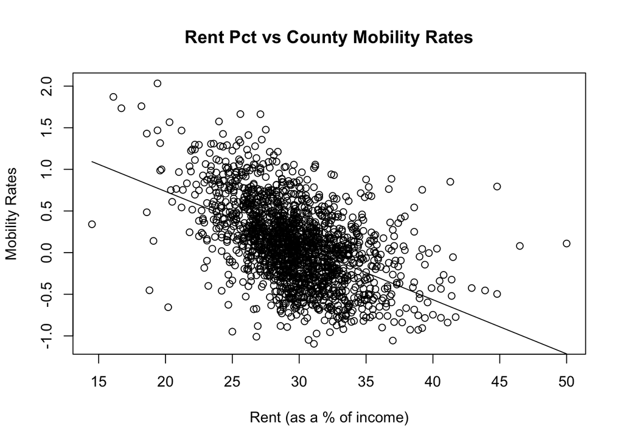

```r
# Scatterplot
plot(data$rentpct, data$mobility, xlab = "Rent (as a % of income)", ylab = "Mobility Rates", main = "Rent Pct vs County Mobility Rates")
curve(regout$coefficients[1] + regout$coefficients[2]*x, add = TRUE)
```

The assumption of constant variance of the residuals (Homoscedasticity) is violated. Visualizing the scatter plot, we can see that the variance isn’t uniform and spreads out at the ends.

#### We cannot interpret these results as evidence for a causal relationship. It’s possible that there are confounding variables. A potential confounding factor within the data set that might be biasing the coefficient on rentpct downwards is the population of college dropouts. It would make sense that as the population of college dropouts increases, the average rent as a percentage of income would increase as well. Another potential confounding factor but outside the data set is the population of people who grew up in a single-parent household. As that population increases, it’s possible that so would rent as a percentage of income.

## Multiple Linear Regression

#### Exploratory Data Analysis

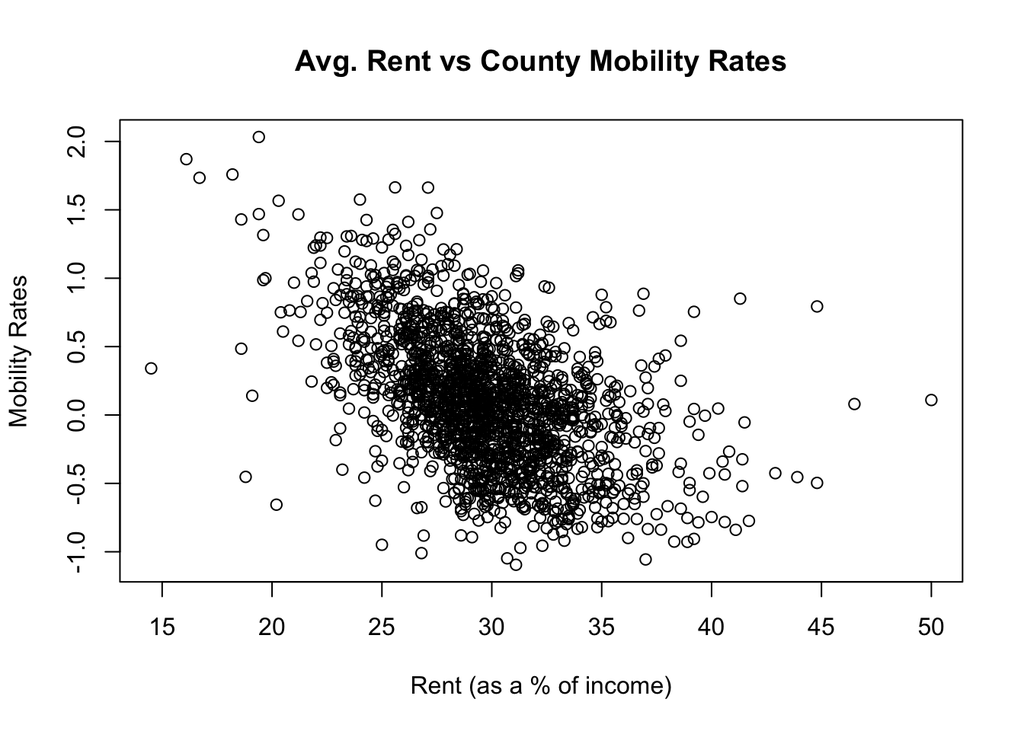

```r
# Include code for plotting below.
plot(data$rentpct, data$mobility, xlab = "Rent (as a % of income)", ylab = "Mobility Rates", main = "Avg. Rent vs County Mobility Rates")
```

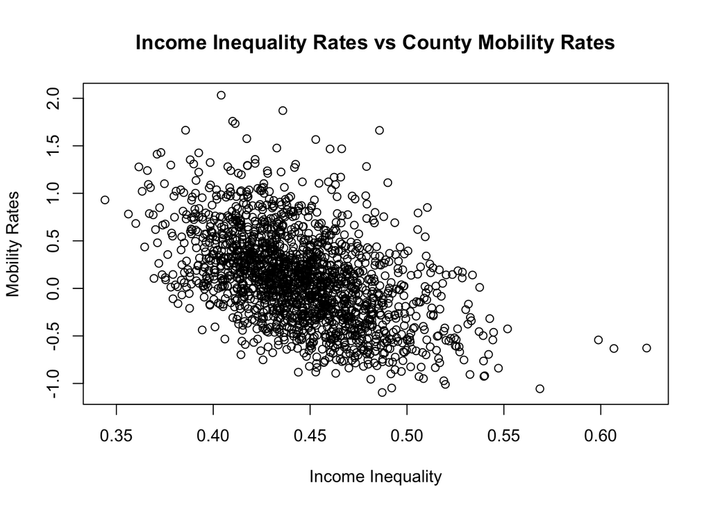

```r
plot(data$gini, data$mobility, xlab = "Income Inequality", ylab = "Mobility Rates", main = "Income Inequality Rates vs County Mobility Rates")
```

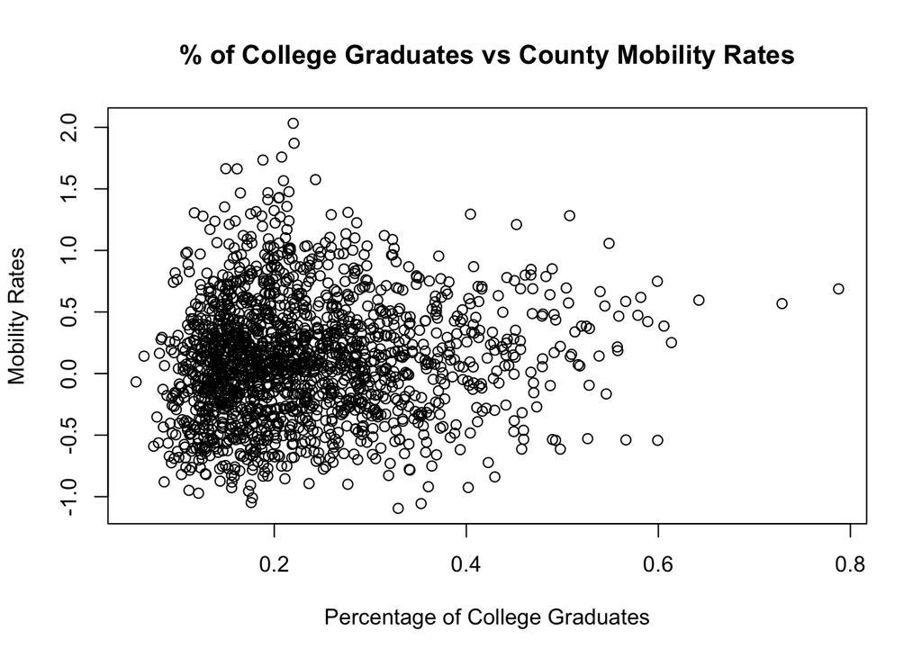

```r
plot(data$college, data$mobility, xlab = "Percentage of College Graduates", ylab = "Mobility Rates", main = "% of College Graduates vs County Mobility Rates")
```

Before visualizing each regression, I’m expecting to see a negative relationship for rentpct and income inequality. But for the population of college graduates, I’d expect a positive relationship. After plotting each one, I’m seeing a weak, negative, linear association between the explanatory variables, rentpct, abd income inequality & mobility. To my surprise, there seems to be a non-linear association between population of college graduates and mobility and it’s very weakly positive.

#### Multicollinearity

```r
# If needed, get help by running the below line
?cor

# Calculate correlation coeffecients
cor(data$gini, data$rentpct)
```

```
## [1] 0.4347794
```

```r
cor(data$gini, data$college)
```

```
## [1] 0.1149809
```

```r
cor(data$college, data$rentpct)
```

```
## [1] 0.1091725
```

#### Regression Implementation

We will regress county mobility rates against the 3 variables.

```r
# Linear Regression Code
Nregout <- lm(data$mobility ~ data$rentpct + data$gini + data$college, data)
summary(Nregout)
```

```
##
## Call:
## lm(formula = data$mobility ~ data$rentpct + data$gini + data$college,
##     data = data)
##
## Residuals:
##      Min       1Q   Median       3Q      Max
## -1.28836 -0.24460 -0.02356  0.23016  1.69484
##
## Coefficients:
##               Estimate Std. Error t value Pr(>|t|)
## (Intercept)   3.551083   0.122121  29.078   <2e-16 ***
## data$rentpct -0.047523   0.002739 -17.351   <2e-16 ***
## data$gini    -5.001765   0.298728 -16.744   <2e-16 ***
## data$college  0.832354   0.092233   9.024   <2e-16 ***
## ---
## Signif. codes:  0 '***' 0.001 '**' 0.01 '*' 0.05 '.' 0.1 ' ' 1
##
## Residual standard error: 0.3778 on 1748 degrees of freedom
## Multiple R-squared:  0.3728, Adjusted R-squared:  0.3717
## F-statistic: 346.4 on 3 and 1748 DF,  p-value: < 2.2e-16
```

```r
regsum <- summary(Nregout)

regsum$r.squared
```

```
## [1] 0.3728253
```

```r
# Hypothesis Testing Code

regsum$coefficients
```

```
##                 Estimate  Std. Error    t value      Pr(>|t|)
## (Intercept)   3.55108311 0.122120723  29.078465 5.750940e-152
## data$rentpct -0.04752332 0.002738902 -17.351233  2.382682e-62
## data$gini    -5.00176487 0.298727711 -16.743558  1.768978e-58
## data$college  0.83235383 0.092232739   9.024494  4.634340e-19
```

```r
b2 <- regsum$coefficients[3,1]
se2 <- regsum$coefficients[3,2]

teststat <- ((b2)/se2)
teststat
```

```
## [1] -16.74356
```

```r
pvalue <- 2*(1-pt(abs(teststat), 1748))
pvalue
```

```
## [1] 0
```

```r
tcr <- qt(1-.01/2, 1748)
tcr
```

```
## [1] 2.578645
```

Looking at the regression, we can see that a unit increase in rentpct will result in a decrease of .048 in mobility. A unit increase in gini (measure of income inequality) will result in a decrease of approximately 5 in mobility. Finally, a unit increase in the population of college graduates will result in an increase of 0.83 in mobility. It’s clear that introducing new variables, accounted for a less drastic slope coefficient for rentpct which makes sense if we consider the correlation between rentpct and gini from earlier. Looking at R^2, we can see that about 37% of the variability in mobility can be explained by the explanatory variables, “gini”, “rentpct”, and “college.”

Because I expected a negative relationship between gini and mobility, I’m interested in testing the significance of beta2:

$$H_0: \beta_2 = 0 \hspace{0.5 in} H_1:
\beta_2 \ne 0.$$
the test statistic is equal to -16.74 which is less than -2.579 indicating that we can reject the null hypothesis. Furthermore, the p value is 0 which is less than alpha so we reject again.

```r
# Code for plotting below

data.red <- data[data$gini >= mean(data$gini) & data$college >= mean(data$college),]

regout2 <- lm(mobility ~ rentpct, data.red)
summary(regout2)
```

```
##
## Call:
## lm(formula = mobility ~ rentpct, data = data.red)
##
## Residuals:
##      Min       1Q   Median       3Q      Max
## -1.04918 -0.28039 -0.01458  0.25036  1.19867
##
## Coefficients:
##              Estimate Std. Error t value Pr(>|t|)
## (Intercept)  0.649509   0.196685   3.302  0.00105 **
## rentpct     -0.022358   0.006168  -3.625  0.00033 ***
## ---
## Signif. codes:  0 '***' 0.001 '**' 0.01 '*' 0.05 '.' 0.1 ' ' 1
##
## Residual standard error: 0.4096 on 367 degrees of freedom
## Multiple R-squared:  0.03456,    Adjusted R-squared:  0.03193
## F-statistic: 13.14 on 1 and 367 DF,  p-value: 0.0003302
```

[figure not shown]

```r
plot(data.red$rentpct, data.red$mobility, xlab = "Income Inequality Rates", ylab = "Mobility Rates", main = "Income Inequality vs County Mobility with Avg. of gini/college grad. const")
```

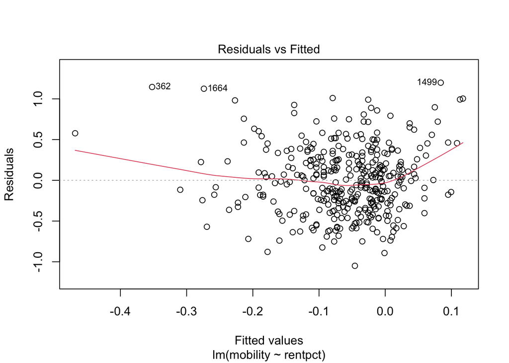

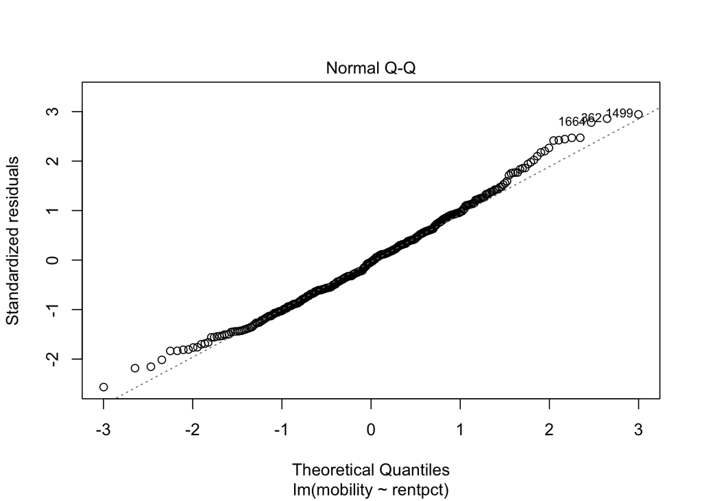

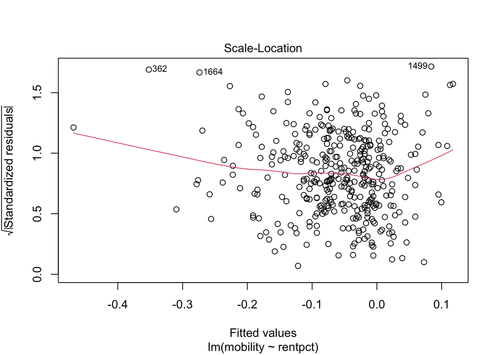

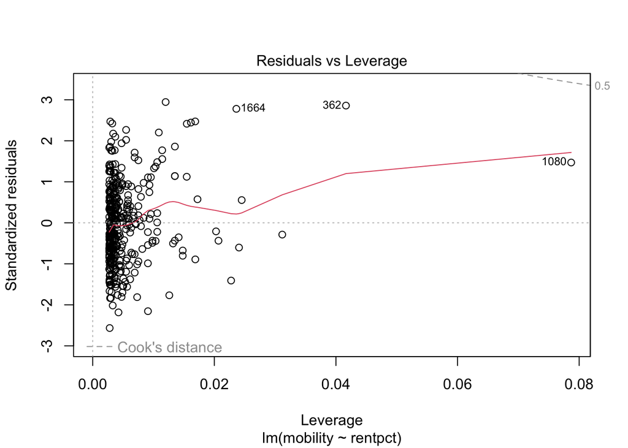

```r
plot(regout2)
```

Using the “Residual vs Fitted” plot, we can see that the variance is pretty consistent and so, homoscedasticity is not violated.

#### Hypothesis Testing

```r
# Code for hypothesis testing
regsum_red <- summary(regout2)
regsum_red
```

```
##
## Call:
## lm(formula = mobility ~ rentpct, data = data.red)
##
## Residuals:
##      Min       1Q   Median       3Q      Max
## -1.04918 -0.28039 -0.01458  0.25036  1.19867
##
## Coefficients:
##              Estimate Std. Error t value Pr(>|t|)
## (Intercept)  0.649509   0.196685   3.302  0.00105 **
## rentpct     -0.022358   0.006168  -3.625  0.00033 ***
## ---
## Signif. codes:  0 '***' 0.001 '**' 0.01 '*' 0.05 '.' 0.1 ' ' 1
##
## Residual standard error: 0.4096 on 367 degrees of freedom
## Multiple R-squared:  0.03456,    Adjusted R-squared:  0.03193
## F-statistic: 13.14 on 1 and 367 DF,  p-value: 0.0003302
```

```r
attributes(regsum_red)
```

```
## $names
##  [1] "call"          "terms"         "residuals"     "coefficients"
##  [5] "aliased"       "sigma"         "df"            "r.squared"
##  [9] "adj.r.squared" "fstatistic"    "cov.unscaled"
##
## $class
## [1] "summary.lm"
```

```r
regsum_red$coefficients
```

```
##               Estimate  Std. Error   t value     Pr(>|t|)
## (Intercept)  0.6495090 0.196685029  3.302280 0.0010532253
## rentpct     -0.0223583 0.006168432 -3.624633 0.0003302098
```

```r
lambda <- 2.60892 + -0.005816962 + 1.414783 + -6.224035
lambda
```

```
## [1] -2.206149
```

```r
n <- 369

vcov(regout2)
```

```
##              (Intercept)       rentpct
## (Intercept)  0.038685000 -1.206088e-03
## rentpct     -0.001206088  3.804955e-05
```

```r
var <- .0518 + 0.773 + 2*(-0.0428)

se <- sqrt(var)

tstat <- ((lambda - 1)/se)
tstat
```

```
## [1] -3.729089
```

```r
pvalue <- 2*(1-pnorm(tstat))
pvalue
```

```
## [1] 1.999808
```

#### Model Selection II

Consider adding three more terms to this model. These terms could be new variables from the dataset, transformations of your existing terms, or interaction terms. For each additional term, provide a short justification for why you are considering adding this specific term. The justification could be based on the scatter plots above or some economic theory justification (diminishing marginal returns, etc.)

Re-run your regression with all these transformed terms (as well as the original terms). Is your adjusted R^2 higher or lower than before? Run an F-test to determine whether adding these new terms significantly increased the explanatory power of the model. State your null hypothesis and alternative hypothesis in terms of the full model parameters. Use level $\alpha = 0.1$ and interpret the conclusions of this test in context.

Put your conclusions below this code chunk.

```r
# Code for new model with transformations
newregout <- lm(data$mobility ~ data$rentpct + data$college + data$gini + data$black + data$income + data$white, data)
newregsum <- summary(newregout)
newregsum
```

```
##
## Call:
## lm(formula = data$mobility ~ data$rentpct + data$college + data$gini +
##     data$black + data$income + data$white, data = data)
##
## Residuals:
##     Min      1Q  Median      3Q     Max
## -1.0067 -0.2191 -0.0278  0.1908  1.2829
##
## Coefficients:
##                Estimate Std. Error t value Pr(>|t|)
## (Intercept)   5.582e-01  2.183e-01   2.557  0.01063 *
## data$rentpct -3.036e-02  2.431e-03 -12.487  < 2e-16 ***
## data$college -2.967e-01  1.370e-01  -2.165  0.03051 *
## data$gini    -1.049e+00  3.287e-01  -3.191  0.00144 **
## data$black   -6.831e-01  1.173e-01  -5.825 6.78e-09 ***
## data$income   1.080e-05  1.505e-06   7.174 1.07e-12 ***
## data$white    8.363e-01  1.112e-01   7.522 8.55e-14 ***
## ---
## Signif. codes:  0 '***' 0.001 '**' 0.01 '*' 0.05 '.' 0.1 ' ' 1
##
## Residual standard error: 0.3185 on 1745 degrees of freedom
## Multiple R-squared:  0.555,  Adjusted R-squared:  0.5535
## F-statistic: 362.7 on 6 and 1745 DF,  p-value: < 2.2e-16
```

```r
# Code for F-Test
SSER <- sum(regout$residuals^2)  # restricted sum of squares
SSEU <- sum(newregout$residuals^2)  # unrestricted sum of squares

df <- nrow(data) - 4

F <- ((SSER - SSEU)/3)/(SSEU/df)
F
```

```
## [1] 398.6697
```

```r
1-pf(F,2,df)
```

```
## [1] 0
```

I added the black population, white population, and income as variables to increase the R-squared value of the model. This model has a better adjusted R-squared value of 0.554.

The p-value is 0 which is less than the significance level, meaning that we can reject the null that the new variables did not significantly increase the explanatory power of the model. The model with the added terms is better.